# SCTC Super Bowl 1k/3k/10k

Aaron Ferrucci

February 8, 2016

On Saturday February 7, 2016, the Santa Cruz Track Club organized three footraces on the west side of Santa Cruz. The weather was perfect - cool and sunny, and it was a nice casual event. My son and I participated in the 10k, which was a nice flat run from the back entrance of Natural Bridges State Park, down West Cliff drive past the lighthouse, almost to the Dream Inn, and then back along the same course.

The SCTC posted the race results online, so I decided to do a little data exploration and analysis.

First, some basic facts.

- Number of participants (all races): 179
- Age range of participants: 2 to 88
  - 1k age range: 2 to 11 (I think some strollers were involved here)
  - 3k age range: 9 to 88
  - 10k age range: 11 to 83
- Running paces (minutes per mile) ranged from 5:05 to 22:23
  - 1k pace range: 5:06 to 22:23
  - 3k pace range: 5:05 to 20:20
  - 10k pace range: 6:06 to 13:14

### Where runners are from

The data lists a city for each runner (but not state or country). Looking over the list, I see mostly identifiably California towns, with a few exceptions (Lahaina, Tucson)

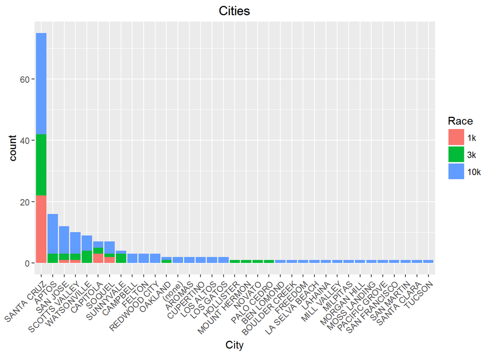

This chart shows where runners are from, broken down by race type. It’s not surprising to see Santa Cruz as the top entry, and cities in Santa Cruz County strongly represented. San Jose and other cities nearby show up in the top 10, and there’s a long tail of cities who sent only a single runner.

Notice that the 1k runners are all from Santa Cruz County, except for one from San Jose.

### 1k results

29 runners participated in the 1k.

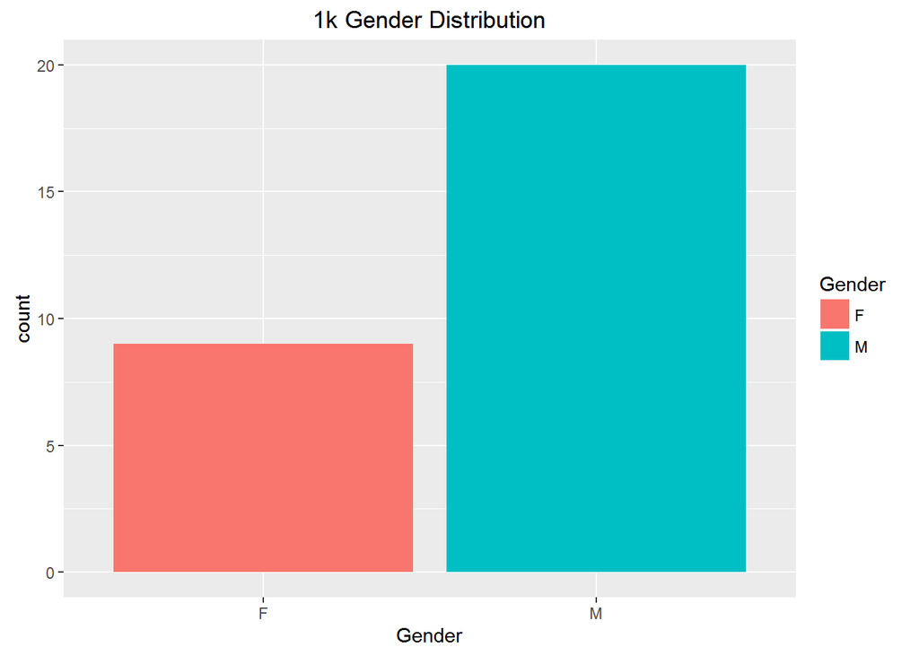

The gender balance for the 1k tilted strongly toward the boys.

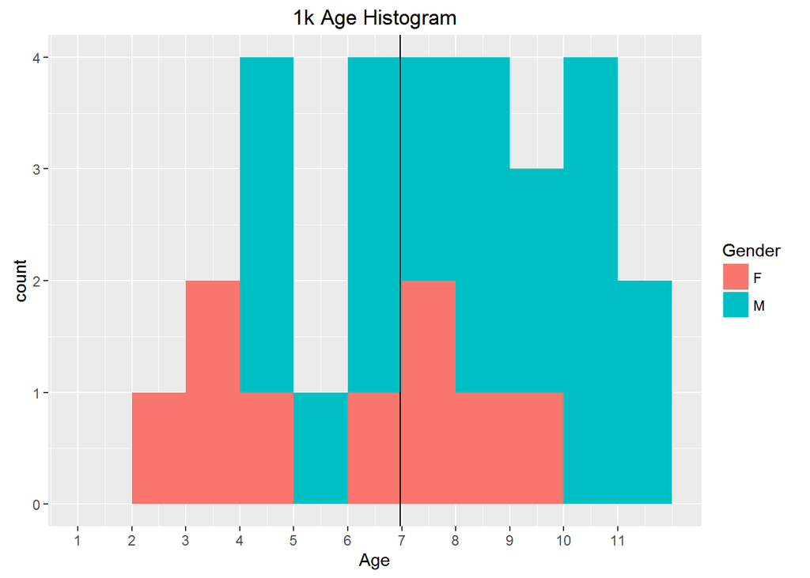

The histogram clearly shows that the 1k was a kids’ event. The average age of a 1k runner was 7. The older runners in the age range tend to be boys.

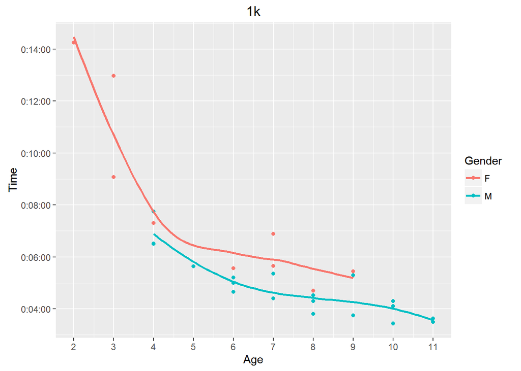

Individual runners are points in the plot; the lines show an average or trend line over the data.

In this age range, being older is an advantage. It’s hard to tell if this is because (in this data set) older runners tend to be boys, and boys might be faster, or if it’s simply a matter of being older.

I am guessing that the three girls aged 3 and under were riding in strollers, but I didn’t see it myself.

### 3k results

42 runners participated in the 3k.

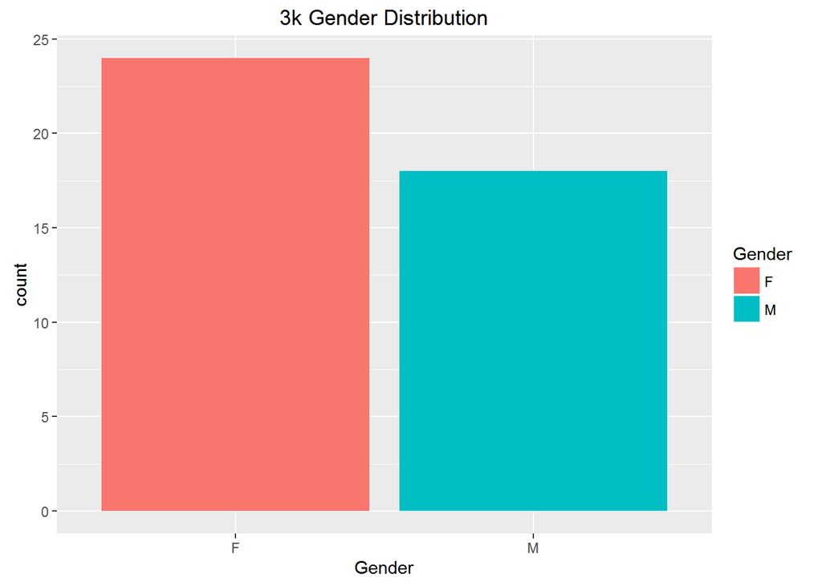

The gender distribution for the 3k is tilted somewhat toward female.

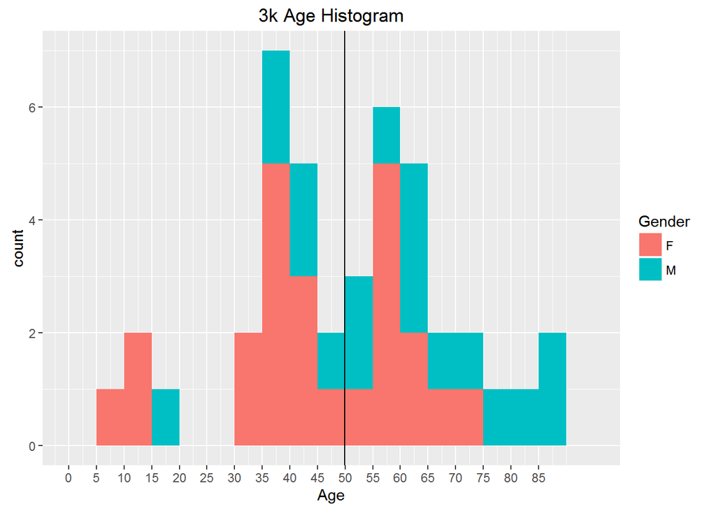

The average age of a 3k runner was 49.9.

The age histogram shows a pretty good age spread, from under 10 to over 80.

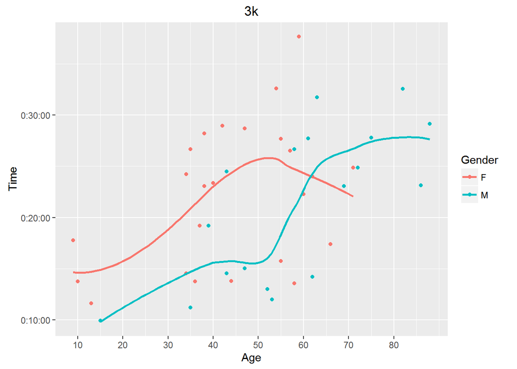

With a small number of runners, we don’t really have meaningful statistics, but nonetheless there seems to be a general upward trend of run time vs. age - except among women 50 years old and older!

### 10k Results

108 runners participated in the 10k.

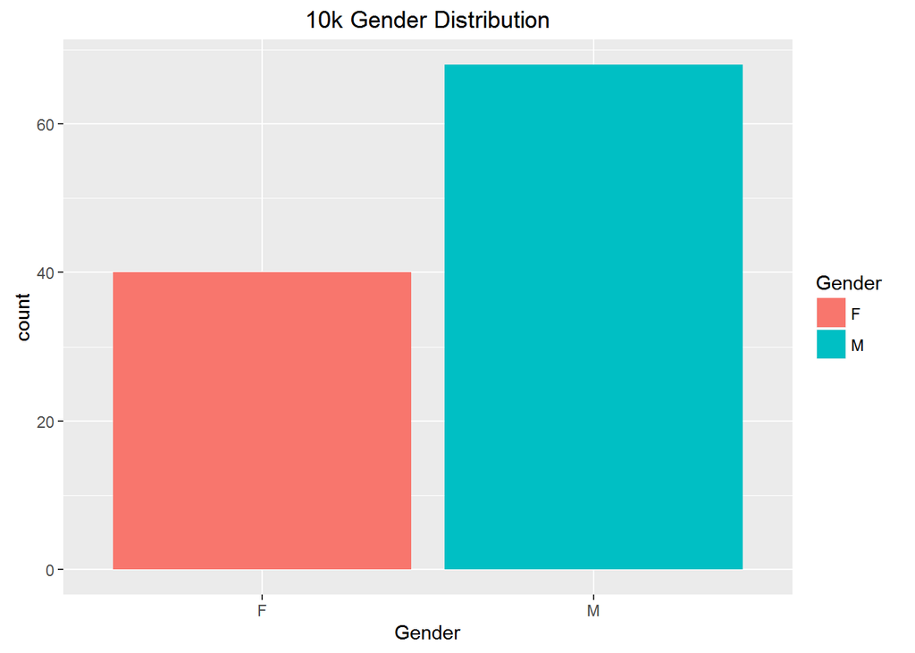

The gender balance for the 10k is tilted more toward male than the 3k was toward female.

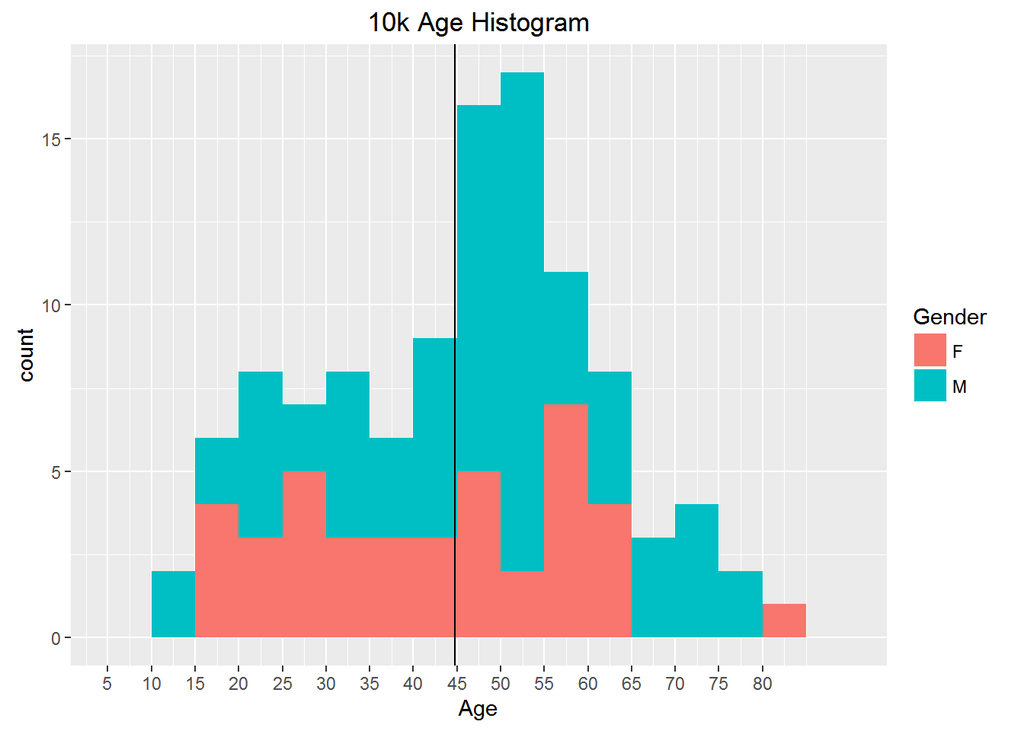

The average age was 44.7.

The age histogram for the 10k race is something of a bell curve. There’s good representation in the 45-60 group.

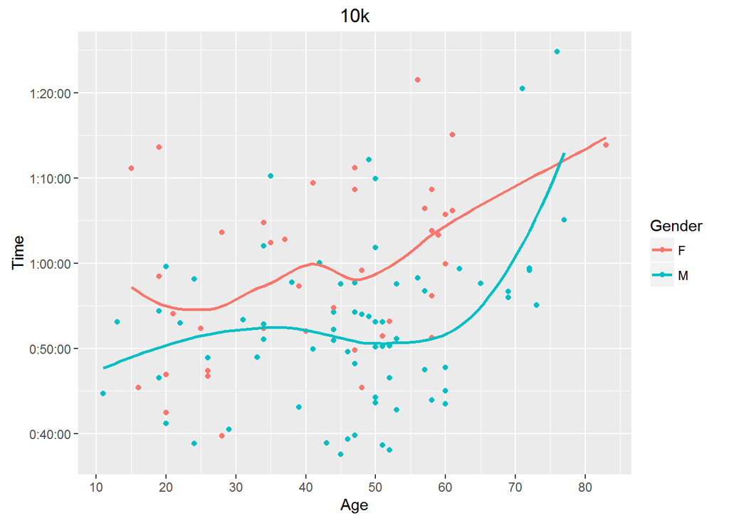

Again, there’s a general upward trend of runtime vs. age, and males are typically faster.

That wraps it up! If I do another revision, I could add an appendix on the web scraping and data cleaning techniques I used - it was a pretty tidy data set, but I did have to filter and rearrange things a bit.